# Lecture 28 - Into Deep Learning P4

This is an [R Markdown](http://rmarkdown.rstudio.com) Notebook

### Lecture 28 - Your project. Deep Learning with H2O. P.4 Implement Deep Learning Model to ShinyApp

Deep Learning… This lecture is dedicated to the implementation of Deep Learning models into for our Data

#### Work overview (from previous lectures)

- Review App
- Reverse Engineer
- Recommendations
- Template to train NN models

#### Review the App

Open Scripts ui.R, server.R and global.R. Run the App…

#### Reverse Engineer

Follow the R scripts and below diagram to find elements of the ShinyApp

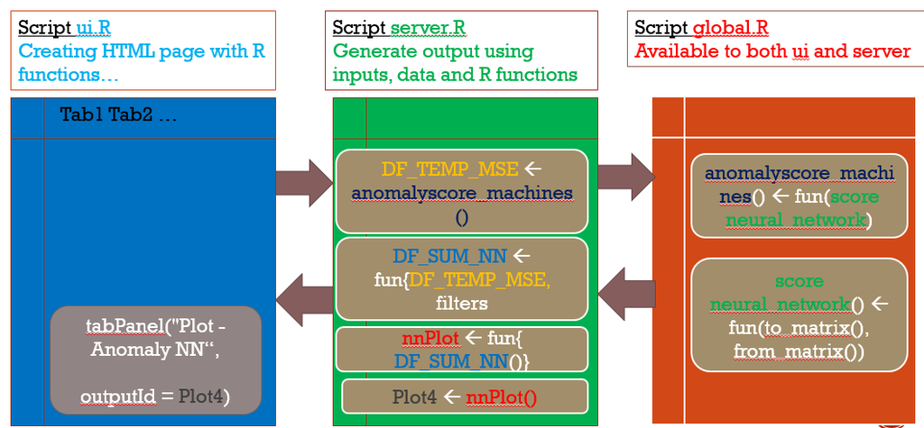

Architecture

#### General Process to Train Models

This code contains a procedure to train Deep Learning models that will make Shiny App working.

This procedure will have to be repeated anytime when h2o source package is updated! Document will contain detailed procefure to select data for one process as well as the code to make a quicker model training.

#### Data preparation

```r
library(tidyverse)
library(plotly)
library(h2o)
# ============= READ DATA =================
# Read our small data ...
DF_Data_Recent <- readRDS("DF_Data_Process_Recent.data")

DF_Equipm <- read_csv("DF_EquipmData.csv")
# data frame containing Event Names
DF_EvCode <- read_csv("DF_EvCodeDataProject.csv")

# Data manipulation and saving to the DF_TEMP
DF_TEMP <- DF_Data_Recent %>%
  # join to decode equipment serial number
  inner_join(DF_Equipm, by = "IDEquipment") %>%
  # join to decode Event Code meaning
  inner_join(DF_EvCode, by = "EventCode") %>%
  # select only column needed
  select(StartDate, Name, AnalogVal, EventText)
```

#### Step by step model generation for one process

It is necessary to visualize the data from several machines to select the data which is more closer to the specifications. ‘Domain’ or ‘Specialist’ knowledge will need to be applied:

```r
# Visualize
DF_TEMP %>%
  filter(EventText == "Tubing Process, phase angle") %>%
  ggplot(aes(x = StartDate, y = AnalogVal, col = Name)) + geom_point()+facet_grid(~Name)
```

Then we will choose the data which will be used for modeling:

```r
# Choose best machine to train model - Machine 1 (Domain Knowldege), extract data
# "Tubing Process, Phase"
DF_TEMP_TPA <- DF_TEMP %>%
  filter(EventText == "Tubing Process, phase angle") %>%
  filter(Name == "Machine #1") %>%
  select(StartDate, AnalogVal) %>%
  arrange(StartDate) %>%
  select(AnalogVal)
```

Data will need to be transformed to the ‘image’ shape:

```r
# transform to 2 matrixes
source("to_m.R")

DF_M1 <- to_m(DF_TEMP_TPA, 150) %>% as.data.frame()
```

We can visualize this shape in 3D

```r
# plotly
plot_ly(z = as.matrix(DF_M1), type = "surface")
```

We are ready to train the model

```r
# to initialize the 'machine'
localH2O = h2o.init()

train_M1 <- as.h2o(x = DF_M1, destination_frame = "train_M1")

normality_model <- h2o.deeplearning(
 x = names(train_M1),
 model_id =  "Tubing Process, phase angle",
 training_frame = train_M1,
 activation = "Tanh",
 autoencoder = TRUE,
 hidden = c(50,20,50),
 sparse = TRUE,
 l1 = 1e-4,
 epochs = 100)

# compute error of the model
h2o.anomaly(normality_model, train_M1) %>% as.data.frame() %>% plot.ts(ylim = c(0, 10), type = "p")

# save model
h2o.saveModel(normality_model, "www/tmp/normality_model.bin")

# shutdown
h2o.shutdown(prompt = F)
```

## Create function

For all of our processes we would need to generate separate models. It is obviously better to write a function to avoid copy/paste and mistakes:

```r
train_model <- function(x, event_text, machine_name, num_cols = 150){
  require(h2o)
  require(tidyverse)
  source("to_m.R")
  # x - dataframe containing prepared data with many events
  # x <- DF_TEMP
  # event_text <- "Tubing Process, phase angle"
  # machine_name <- "Machine #4"
  # num_cols <- 150
  # h2o.init()
  DF_TEMP_TPA <- x %>%
  filter(EventText == event_text) %>%
  filter(Name == machine_name) %>%
  select(StartDate, AnalogVal) %>%
  arrange(StartDate) %>%
    select(AnalogVal)

  DF_M1 <- to_m(DF_TEMP_TPA, num_cols) %>% as.data.frame()

  train_M1 <- as.h2o(x = DF_M1, destination_frame = "train_M1")

  # model id must not have any commas or alike!
  my_mod <- str_remove_all(event_text, ",") %>% str_remove_all(" ")

  normality_model <- h2o.deeplearning(
   x = names(train_M1),
   model_id =  my_mod,
   training_frame = train_M1,
   activation = "Tanh",
   autoencoder = TRUE,
   hidden = c(50,20,50),
   sparse = TRUE,
   l1 = 1e-4,
   epochs = 50)

  # save model
  h2o.saveModel(normality_model, "www/tmp/normality_model.bin",force = T)

}
```

## Create many models using one function

```r
DF_TEMP %>% select(EventText) %>% unique()
```

Nota Bene!!! this code may run ~ 5-10 minutes!!!

```r
# to initialize the 'machine'
h2o.init(nthreads = 2)

## -------------------
# 1. Process Tubing Process, phase angle
## -------------------
# Visualize
DF_TEMP %>%
  filter(EventText == "Tubing Process, phase angle") %>%
  ggplot(aes(x = StartDate, y = AnalogVal, col = Name)) + geom_point()+facet_grid(~Name)

# Train the model using defined function
train_model(x = DF_TEMP, event_text = "Tubing Process, phase angle",machine_name = "Machine #4")

## -------------------
# 2. Process Edging Process, resistance Ohm
## -------------------
# Visualize to choose the best machine (using Domain knowledge)
DF_TEMP %>%
  filter(EventText == "Edging Process, resistance Ohm") %>%
  ggplot(aes(x = StartDate, y = AnalogVal, col = Name)) + geom_point()+facet_grid(~Name)

# Train the model using defined function
train_model(x = DF_TEMP, event_text = "Edging Process, resistance Ohm",machine_name = "Machine #4")


## -------------------
# 3. Process Cutting Process, resistance Ohm
## -------------------
# Visualize to choose the best machine (using Domain knowledge)
DF_TEMP %>%
  filter(EventText == "Cutting Process, resistance Ohm") %>%
  ggplot(aes(x = StartDate, y = AnalogVal, col = Name)) + geom_point()+facet_grid(~Name)

# Train the model using defined function
train_model(x = DF_TEMP, event_text = "Cutting Process, resistance Ohm",machine_name = "Machine #4")

## -------------------
# 4. Process Edging Process, resistance Ohm
## -------------------
# Visualize to choose the best machine (using Domain knowledge)
DF_TEMP %>%
  filter(EventText == "Tubing Process, resistance Ohm") %>%
  ggplot(aes(x = StartDate, y = AnalogVal, col = Name)) + geom_point()+facet_grid(~Name)

# Train the model using defined function
train_model(x = DF_TEMP, event_text = "Tubing Process, resistance Ohm",machine_name = "Machine #1")

## -------------------
# 5. Process Edging Process, resistance Ohm
## -------------------
# Visualize to choose the best machine (using Domain knowledge)
DF_TEMP %>%
  filter(EventText == "Cutting Process, phase angle") %>%
  ggplot(aes(x = StartDate, y = AnalogVal, col = Name)) + geom_point()+facet_grid(~Name)

# Train the model using defined function
train_model(x = DF_TEMP, event_text = "Cutting Process, phase angle",machine_name = "Machine #2")

## -------------------
# 6. Process Edging Process, phase angle
## -------------------
# Visualize to choose the best machine (using Domain knowledge)
DF_TEMP %>%
  filter(EventText == "Edging Process, phase angle") %>%
  ggplot(aes(x = StartDate, y = AnalogVal, col = Name)) + geom_point()+facet_grid(~Name)

# Train the model using defined function
train_model(x = DF_TEMP, event_text = "Edging Process, phase angle",machine_name = "Machine #4")


# shutdown
h2o.shutdown(prompt = F)
```